# Assignment 2

Julie Bang Mikkelsen (AU718507)

January 7th 2025

# Loading packages

```r
library(dslabs)
library(car)
library(ggplot2)
library(dplyr)
```

# Part 1

## Loading data

```r
data('divorce_margarine')
d <- divorce_margarine
str(d)
```

```
## 'data.frame':    10 obs. of  3 variables:
##  $ divorce_rate_maine              : num  5 4.7 4.6 4.4 4.3 4.1 4.2 4.2 4.2 4.1
##  $ margarine_consumption_per_capita: num  8.2 7 6.5 5.3 5.2 4 4.6 4.5 4.2 3.7
##  $ year                            : int  2000 2001 2002 2003 2004 2005 2006 2007 2008 2009
```

## Inspecting correlation between margarine consumption and divorce rates

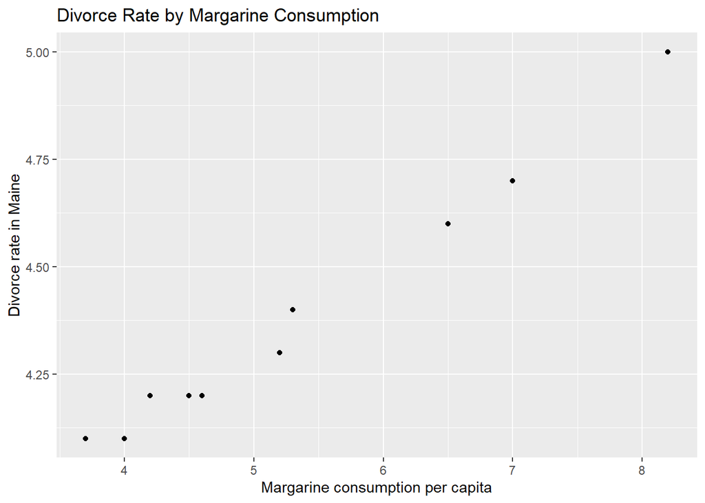

```r
# Inspecting the data as plot
ggplot(d, aes(margarine_consumption_per_capita, divorce_rate_maine)) +
  geom_point() +
  labs(
    x = "Margarine consumption per capita",
    y = "Divorce rate in Maine",
    title = "Divorce Rate by Margarine Consumption")
```

It looks like there is a positive relationship between the two.

```r
# Running a correlation
cor.test(d$margarine_consumption_per_capita, d$divorce_rate_maine)
```

```
##
##  Pearson's product-moment correlation
##
## data:  d$margarine_consumption_per_capita and d$divorce_rate_maine
## t = 23.055, df = 8, p-value = 1.33e-08
## alternative hypothesis: true correlation is not equal to 0
## 95 percent confidence interval:
##  0.9676666 0.9983038
## sample estimates:
##       cor
## 0.9925585
```

Looking at the correlation results, it appears that there is a strong positive correlation between the two variables.

```r
# Fitting a model
summary(lm(divorce_rate_maine ~ margarine_consumption_per_capita, d))
```

```
##
## Call:
## lm(formula = divorce_rate_maine ~ margarine_consumption_per_capita,
##     data = d)
##
## Residuals:
##      Min       1Q   Median       3Q      Max
## -0.05583 -0.01816 -0.01452  0.03601  0.04625
##
## Coefficients:
##                                  Estimate Std. Error t value Pr(>|t|)
## (Intercept)                      3.308626   0.048032   68.88 2.20e-12 ***
## margarine_consumption_per_capita 0.201386   0.008735   23.05 1.33e-08 ***
## ---
## Signif. codes:  0 '***' 0.001 '**' 0.01 '*' 0.05 '.' 0.1 ' ' 1
##
## Residual standard error: 0.03841 on 8 degrees of freedom
## Multiple R-squared:  0.9852, Adjusted R-squared:  0.9833
## F-statistic: 531.5 on 1 and 8 DF,  p-value: 1.33e-08
```

Inspecting the model summary, there is a significant positive association between margarine consumption and divorce rate. The effect size appears to be that when margarine consumption is increased with 1 unit, the divorce rate increases with .2 unit.

# Part 2

## Loading data

```r
data(GSSvocab)
d2 <- GSSvocab
str(d2)
```

```
## 'data.frame':    28867 obs. of  8 variables:
##  $ year      : Factor w/ 20 levels "1978","1982",..: 1 1 1 1 1 1 1 1 1 1 ...
##  $ gender    : Factor w/ 2 levels "female","male": 1 1 2 1 1 2 2 2 1 2 ...
##  $ nativeBorn: Factor w/ 2 levels "no","yes": 2 2 2 2 2 2 2 2 2 2 ...
##  $ ageGroup  : Factor w/ 5 levels "18-29","30-39",..: 4 5 2 4 3 1 1 4 3 1 ...
##  $ educGroup : Factor w/ 5 levels "<12 yrs","12 yrs",..: 2 1 1 2 2 2 2 2 4 2 ...
##  $ vocab     : num  10 6 4 9 6 6 4 7 8 3 ...
##  $ age       : num  52 74 35 50 41 19 19 59 49 21 ...
##  $ educ      : num  12 9 10 12 12 12 12 12 16 12 ...
```

## Filtering data

```r
d2 <- d2 %>%
  filter(year == '1978') %>%
  na.omit(d2)
```

## Inspecting the relationship between vocab and education

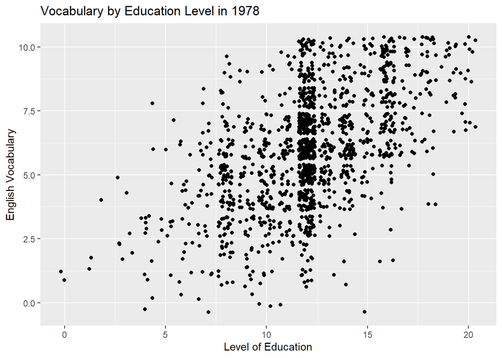

```r
# Visually inspecting with plot
ggplot(d2,
       aes(educ, vocab)) +
  geom_point(position = 'jitter') +
  labs(
    x = "Level of Education",
    y = "English Vocabulary",
    title = "Vocabulary by Education Level in 1978")
```

Looking at the plot, it appears that there is a positive relationship between the two variables.

```r
# Fitting a model
summary(lm(vocab ~ educ, d2))
```

```
##
## Call:
## lm(formula = vocab ~ educ, data = d2)
##
## Residuals:
##     Min      1Q  Median      3Q     Max
## -7.1233 -1.1608  0.0542  1.0917  5.6243
##
## Coefficients:
##             Estimate Std. Error t value Pr(>|t|)
## (Intercept)  1.23567    0.19957   6.192  7.7e-10 ***
## educ         0.39251    0.01606  24.443  < 2e-16 ***
## ---
## Signif. codes:  0 '***' 0.001 '**' 0.01 '*' 0.05 '.' 0.1 ' ' 1
##
## Residual standard error: 1.885 on 1475 degrees of freedom
## Multiple R-squared:  0.2883, Adjusted R-squared:  0.2878
## F-statistic: 597.5 on 1 and 1475 DF,  p-value: < 2.2e-16
```

Inspecting the model summary, it appears that education significantly affects vocabulary (p < 0.001), with an effect size of .39 increase in vocab for every 1 increase in education.

## Adding nativeBorn as predictor

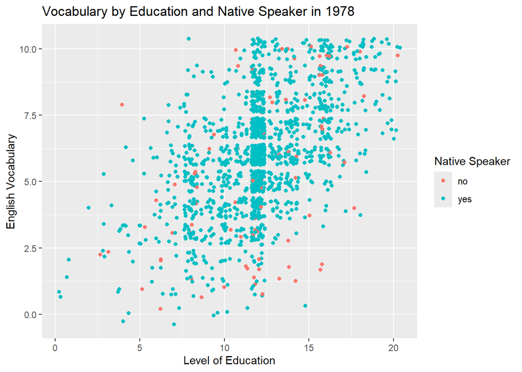

```r
# Visualizing the relationship between nativeBorn and vocab
ggplot(d2,
       aes(educ, vocab, col = nativeBorn)) +
  geom_point(position = 'jitter') +
  labs(
    x = "Level of Education",
    y = "English Vocabulary",
    title = "Vocabulary by Education and Native Speaker in 1978",
    color = "Native Speaker")
```

```r
# Fitting a model
summary(lm(vocab ~ educ + nativeBorn, d2))
```

```
##
## Call:
## lm(formula = vocab ~ educ + nativeBorn, data = d2)
##
## Residuals:
##    Min     1Q Median     3Q    Max
## -7.162 -1.200  0.015  1.231  5.803
##
## Coefficients:
##               Estimate Std. Error t value Pr(>|t|)
## (Intercept)    0.62803    0.27651   2.271  0.02327 *
## educ           0.39222    0.01601  24.499  < 2e-16 ***
## nativeBornyes  0.65032    0.20551   3.164  0.00159 **
## ---
## Signif. codes:  0 '***' 0.001 '**' 0.01 '*' 0.05 '.' 0.1 ' ' 1
##
## Residual standard error: 1.879 on 1474 degrees of freedom
## Multiple R-squared:  0.2931, Adjusted R-squared:  0.2921
## F-statistic: 305.6 on 2 and 1474 DF,  p-value: < 2.2e-16
```

Visually inspecting the relationship, there is no clear effect of nativeBorn on vocabulary, but after fitting the model, it appears that apart from education, being a native English speaker significantly contributes to a person’s vocabulary (p < .01).

## Inspecting the relationship between education and nativeBorn

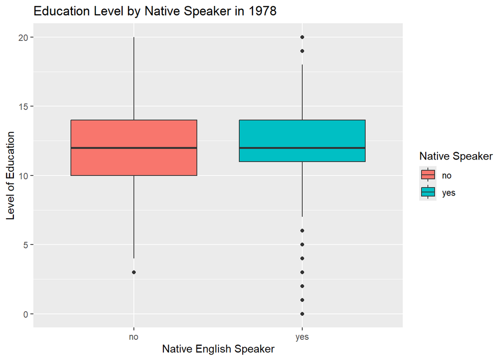

```r
# Visualizing the relationship between nativeborn and education
ggplot(d2, aes(nativeBorn, educ, fill = nativeBorn)) +
  geom_boxplot() +
  labs(
    x = "Native English Speaker",
    y = "Level of Education",
    title = "Education Level by Native Speaker in 1978",
    fill = "Native Speaker")
```

```r
# Fitting a model on education
summary(lm(educ ~ nativeBorn, d2))
```

```
##
## Call:
## lm(formula = educ ~ nativeBorn, data = d2)
##
## Residuals:
##      Min       1Q   Median       3Q      Max
## -12.0512  -1.0512  -0.0512   1.9488   8.0225
##
## Coefficients:
##               Estimate Std. Error t value Pr(>|t|)
## (Intercept)   11.97753    0.32401   36.97   <2e-16 ***
## nativeBornyes  0.07362    0.33423    0.22    0.826
## ---
## Signif. codes:  0 '***' 0.001 '**' 0.01 '*' 0.05 '.' 0.1 ' ' 1
##
## Residual standard error: 3.057 on 1475 degrees of freedom
## Multiple R-squared:  3.29e-05,   Adjusted R-squared:  -0.000645
## F-statistic: 0.04852 on 1 and 1475 DF,  p-value: 0.8257
```

```r
# Fitting an interaction model on vocab
summary(lm(vocab ~ educ * nativeBorn, d2))
```

```
##
## Call:
## lm(formula = vocab ~ educ * nativeBorn, data = d2)
##
## Residuals:
##     Min      1Q  Median      3Q     Max
## -7.1554 -1.2049  0.0149  1.2347  5.9857
##
## Coefficients:
##                    Estimate Std. Error t value Pr(>|t|)
## (Intercept)         0.35394    0.68780   0.515    0.607
## educ                0.41510    0.05496   7.553 7.45e-14 ***
## nativeBornyes       0.95000    0.71855   1.322    0.186
## educ:nativeBornyes -0.02501    0.05745  -0.435    0.663
## ---
## Signif. codes:  0 '***' 0.001 '**' 0.01 '*' 0.05 '.' 0.1 ' ' 1
##
## Residual standard error: 1.88 on 1473 degrees of freedom
## Multiple R-squared:  0.2932, Adjusted R-squared:  0.2917
## F-statistic: 203.7 on 3 and 1473 DF,  p-value: < 2.2e-16
```

## Comparing models

```r
m1 <- lm(vocab ~ educ, d2)
m2 <- lm(vocab ~ educ + nativeBorn, d2)
m3 <- lm(vocab ~ educ * nativeBorn, d2)

anova(m1, m2, m3)
```

```
## Analysis of Variance Table
##
## Model 1: vocab ~ educ
## Model 2: vocab ~ educ + nativeBorn
## Model 3: vocab ~ educ * nativeBorn
##   Res.Df    RSS Df Sum of Sq       F  Pr(>F)
## 1   1475 5241.8
## 2   1474 5206.5  1    35.371 10.0083 0.00159 **
## 3   1473 5205.8  1     0.670  0.1894 0.66344
## ---
## Signif. codes:  0 '***' 0.001 '**' 0.01 '*' 0.05 '.' 0.1 ' ' 1
```

Inspecting the anova results, it appears that there is a significant difference between m1 and m2, but not between m2 and m3. This indicates that adding nativeBorn as a predictor significantly improves the model fit, however adding an interaction between them does not. In other words, a person’s vocabulary is affected by their education level and status as native english speaker, but being native english speaker does not impact their education level. Overall, m2 appears to be the best model.